# Functions and For Loops

Module 4

Clemens S. Heithecker

# Setup

In this module we use the tidyverse package to manipulate data frames.

```r
library(tidyverse)
```

# Functions

In programming, functions are used to automate or repeat common tasks.

A function can have multiple **arguments**. For example the `mean()` function accepts three arguments:

- `x` which is a vector of numbers for which to calculate the mean
- `trim` which is an *optional argument* to specify numbers to be ignored when calculating the mean
- `na.rm` which is again an *optional argument* indicating whether missing values should be removed before calculating the mean

The arguments of a function are documented in the functions documentation. Here you can find more information about the function including examples. You can access the documentation of a function by writing a question mark in front of it.

```r
?mean
```

```
## starting httpd help server ... done
```

Note that the arguments `trim` and `na.rm` both have a default value (`0` and `FALSE` respectively). This means the arguments are **optional** and don’t need to be specified when using the function.

For example:

```r
vector <- c(1, 2, 3, NA)

mean(vector)
```

```
## [1] NA
```

```r
mean(vector, na.rm = FALSE)
```

```
## [1] NA
```

```r
mean(vector, na.rm = TRUE)
```

```
## [1] 2
```

## Exercise 1—Arguments of a Function

What are the arguments for the `sum()` function and which arguments are required and which ones optional?

```r
?sum

# Required arguments
# - a vector of numeric, complex or logical values

# Optional arguments
# - na.rm indicating whether missing values should be removed before calculating
# the sum
```

## Exercise 2—Predicting the Output of a Function

Look up the arguments of the `log()` function. Then, predict which of the following calls does not return an error:

- `log(x = 100, 10)`
- `log(100)`
- `log(base = exp(1))`
- `log(exp(1) ^ 3, exp(1))`
- `log(base = 10, x = 100)`

```r
# Required arguments of the log() function:
# - x

# Optional arguments of the log() function:
# - base (defaults to exp(1))

# This function should work as the required argument is provided and base is
# given as a second argument
log(x = 100, 10)
```

```
## [1] 2
```

```r
# This function should work because the required argument x is provided
log(100)
```

```
## [1] 4.60517
```

```r
# This function should not work because x is not given
# log(base = exp(1))

# This function should work as both x and base are implicitly provided
log(exp(1) ^ 3, exp(1))
```

```
## [1] 3
```

```r
# This function should work because both arguments are explicitly provided which
# is important because of the altered order
log(base = 10, x = 100)
```

```
## [1] 2
```

The key takeaway from this exercise is that the order of the arguments provided matters when the specific arguments used are not explicitly specified (`log(100)` instead of `log(x = 100)`).

# Creating a Custom Function

We can create our own function using the `function` command. Let’s make a function that accepts a vector `x` and returns the square of the vector.

```r
square <- function(x) {
  x * x
}
```

The function `square` returns the square of the elements of an input vector `x`:

```r
square(2)
```

```
## [1] 4
```

```r
a <- 3
square(a)
```

```
## [1] 9
```

```r
b <- c(1, 3)
square(b)
```

```
## [1] 1 9
```

`R` treats all variables as vectors as the example above shows.

Just like the `mean()` and the `log()` functions we examined above, we can pass multiple arguments to our custom function.

```r
square_plus <- function(x, y = 1) {
  x * x + y
}

square_plus(3, 6)
```

```
## [1] 15
```

```r
square_plus(3)
```

```
## [1] 10
```

The function above takes in two *input* variables and returns a single *output*. Thereby the argument`x` is required and `y` optional which defaults to 1 if it is not explicitly specified.

## Exercise 3—Writing a Custom Function

Create a function called `paste_together` that takes two variables as *input* and pastes them together with the R base function `paste`.

```r
paste_together <- function(x, y) {
  # This function pastes two strings together

  paste(x, y)
}

# Testing the function
paste_together("house number", 45)
```

```
## [1] "house number 45"
```

```r
paste_together("letter", LETTERS)
```

```
##  [1] "letter A" "letter B" "letter C" "letter D" "letter E" "letter F"
##  [7] "letter G" "letter H" "letter I" "letter J" "letter K" "letter L"
## [13] "letter M" "letter N" "letter O" "letter P" "letter Q" "letter R"
## [19] "letter S" "letter T" "letter U" "letter V" "letter W" "letter X"
## [25] "letter Y" "letter Z"
```

# The For Loop

According to [Wikipedia](https://en.wikipedia.org/wiki/For_loop):

> In computer science, a for-loop (or simply for loop) is a control flow statement for specifying iteration, which allows code to be executed repeatedly. […]

> A for-loop has two parts: a header specifying the iteration, and a body which is executed once per iteration. The header often declares an explicit loop counter or loop variable, which allows the body to know which iteration is being executed. For-loops are typically used when the number of iterations is known before entering the loop.

For example:

```r
for (i in 1:10) {
  print(i)
}
```

```
## [1] 1
## [1] 2
## [1] 3
## [1] 4
## [1] 5
## [1] 6
## [1] 7
## [1] 8
## [1] 9
## [1] 10
```

## Exercise 4—Using a For Loop

Create a function that calls the function `squared_plus()` from before for the numbers `x` to `x + 10` and adds the results returning the total.

```r
loop_function <- function(x) {
  total <- 0

  for (i in x:(x + 10)) {
    total <- total + square_plus(i)
  }

  return(total)
}

# Testing the function
loop_function(2)
```

```
## [1] 660
```

## Exercise 5—A Function to Calcuate the Variance

The variance of a set of numbers $X$ is a **statistic** (a number that is derived from other numbers using a statistical procedure or algorithm) that quantifies the amount of spread in the values. Informally, it measures how far a set of numbers is spread out from its average value.

$$\text{Variance}(X) = \text{Mean}(X^2) - (\text{Mean}(X))^2$$

Create a function that calculates the variance of a numeric vector.

```r
variance <- function(x) {
  mean(x ^ 2) - mean(x) ^ 2
}
```

```r
vec <- c(2, 4, 3, 6)

N <- length(vec)
corr <- N / (N - 1)

result <- variance(vec) * corr
result
```

```
## [1] 2.916667
```

```r
test <- var(vec)
test
```

```
## [1] 2.916667
```

```r
result == test
```

```
## [1] TRUE
```

# When Should I Use Functions?

**Code repetition** is a good signal for when to use a function. As soon as you start copying and re-using code it makes sense to turn that chunk of code into a function.

For example, suppose we are interested in global exports of clothing in 2018. Which countries are the top exporting countries and to which countries do they export to?

## Exercise 6—Loading the Data

Load the `trade.rds` data set using `readRDS()`. Then, filter all entries from the year 2018. How many distinct countries does the data set contain?

```r
trade_2018 <- readRDS("data/trade.rds") %>%
  filter(year == 2018)

head(trade_2018)
```

| year | reporter_iso | reporter_fullname_english | partner_iso | partner_fullname_english | export_value_usd | import_value_usd |
| --- | --- | --- | --- | --- | --- | --- |
| 2018 | afg | Afghanistan | are | United Arab Emirates | 9.8470e-05 | 0.002699055 |
| 2018 | afg | Afghanistan | arg | Argentina | 1.0170e-06 | 0.000000000 |
| 2018 | afg | Afghanistan | aus | Australia | 1.1780e-06 | 0.000000000 |
| 2018 | afg | Afghanistan | aut | Austria | 3.4114e-05 | 0.000042655 |
| 2018 | afg | Afghanistan | bdi | Burundi | 7.4000e-08 | 0.000000000 |
| 2018 | afg | Afghanistan | bel | Belgium (Belgium-Luxembourg Customs Union until 1999) | 5.1320e-06 | 0.000047744 |

```r
length(unique(trade_2018$reporter_iso))
```

```
## [1] 225
```

Let’s start by analyzing China which is the country with the largest clothing exports.

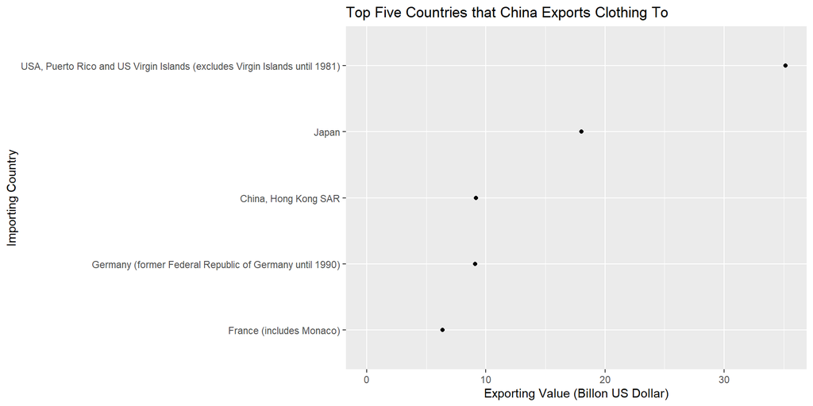

```r
temp <- trade_2018 %>%
  # Select China as the reporter
  filter(reporter_iso == "chn") %>%
  # Group by year
  group_by(year) %>%
  # Select the 5 largest trading partners with China measured by the export
  # value in USD
  slice_max(order_by = export_value_usd, n = 5)

# Extract the country names from the data set
country_name <- unique(temp$reporter_fullname_english)

plot_title <- paste("Top Five Countries that",
                    country_name,
                    "Exports Clothing To")

ggplot(data = temp, mapping = aes(x = reorder(partner_fullname_english,
                                              export_value_usd),
                                  y = export_value_usd)) +
  geom_point() +
  expand_limits(y = 0) +
  ggtitle(plot_title) +
  xlab("Importing Country") +
  ylab("Exporting Value (Billon US Dollar)") +
  coord_flip()
```

Suppose we want to make a similar plot for a list of countries. Let’s say we are interested in India (*ind*), Bangladesh (*bgd*), Italy (*ita*) and Germany (*deu*) in addition to China.

Let’s turn the code that generates the plot into a function.

## Exercise 7—Using a Function to Plot Data

Turn the previous code chunk into a function that takes the data set and a country code as arguments and creates a plot similar to the one above for the supplied country.

```r
plot_top_five_partner_countries <- function(df, country_code) {
  temp <- df %>%
  # Select the provided country as the reporter
  filter(reporter_iso == country_code) %>%
  # Group by year
  group_by(year) %>%
  # Select the 5 largest trading partners measured by the export value in USD
  slice_max(order_by = export_value_usd, n = 5)

  # Extract the country names from the data set
  country_name <- unique(temp$reporter_fullname_english)

  plot_title <- paste("Top Five Countries that",
                      country_name,
                      "Exports Clothing To")

  ggplot(data = temp, mapping = aes(x = reorder(partner_fullname_english,
                                                export_value_usd),
                                    y = export_value_usd)) +
    geom_point() +
    expand_limits(y = 0) +
    ggtitle(plot_title) +
    xlab("Importing Country") +
    ylab("Exporting Value (Billon US Dollar)") +
    coord_flip()
}
```

Let’s see if it works by creating the plot for Germany.

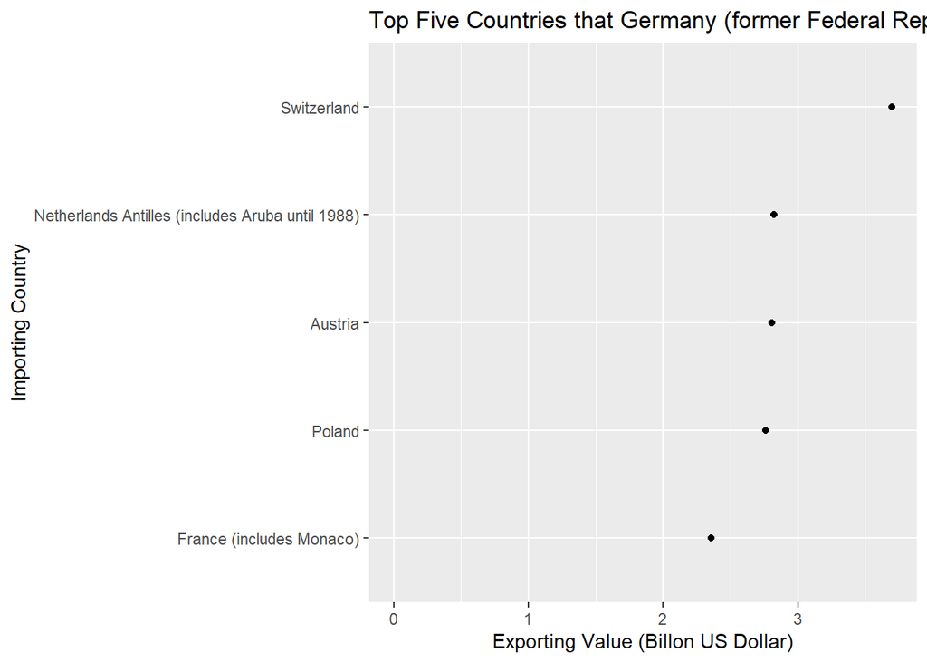

```r
plot_top_five_partner_countries(trade_2018, country_code = "deu")
```

Now we can use a for loop to plot every country in a given vector.

```r
countries <- c("bgd", "chn", "deu", "ind", "ita")
```

## Exercise 8—A Plot for Every Country

Write a for loop that calls the `plot_top_five_partner_countries()` function for each country in `countries`. Use the `length()` function to obtain the number of times the loop needs to be executed.

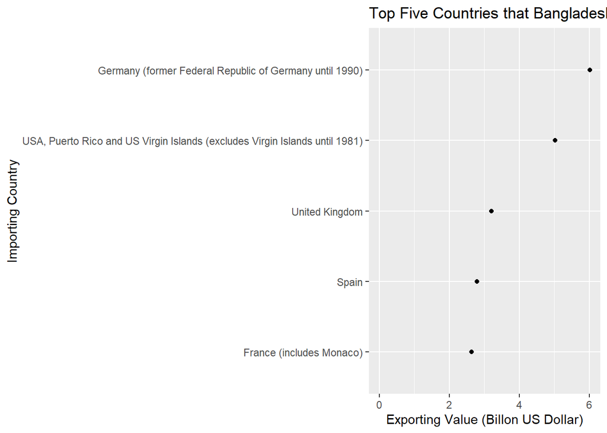

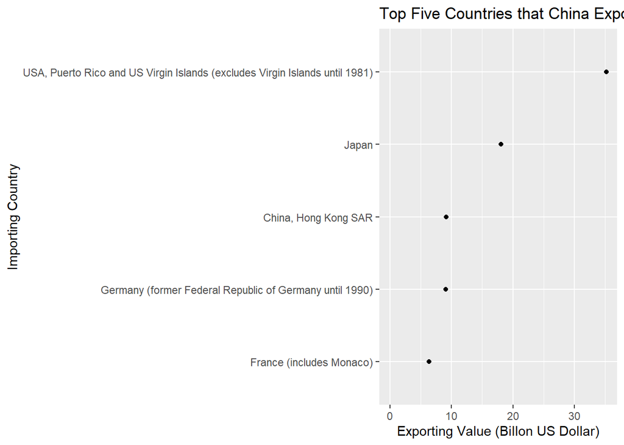

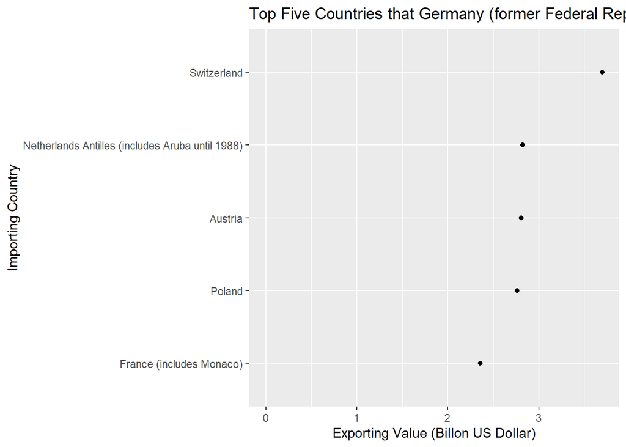

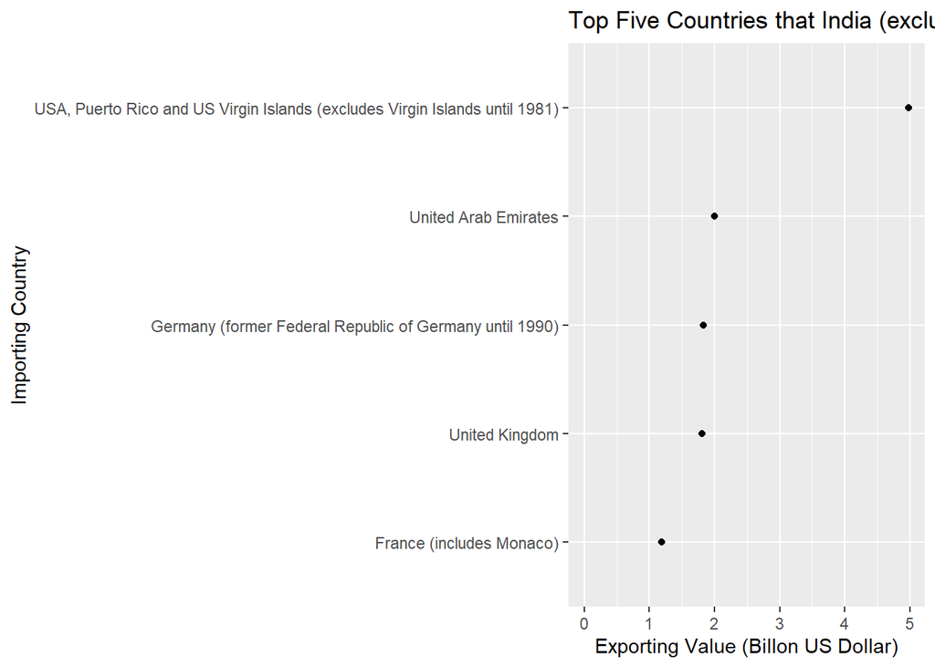

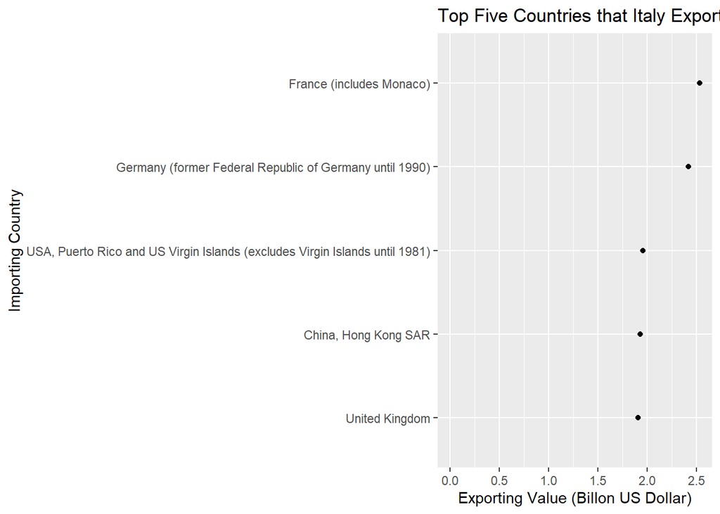

```r
for (country in 1:length(countries)) {
  print(
    plot_top_five_partner_countries(df = trade_2018,
                                    country_code = countries[country])
  )
}
```

# Further Readings

- [A Tutorial on Using Functions in R! - DataCamp](https://www.datacamp.com/community/tutorials/functions-in-r-a-tutorial)
- [Functions - R for Data Science](https://r4ds.had.co.nz/functions.html)